# Waal Intrinsic Variables and Parental Care Coordination Model Script

Fionnuala R McCully

19/08/2021

# Wandering Albatross Model Script

This R Markdown document details the code used to generate the results for a study on the impact of intrinsic variables on parental care coordination in wandering albatrosses. It covers the refinement of the data to create a data set suitable for analysis, the mixed models used to analyse the data and the creation of the graphs used to display the data.

## Data Setup, Descriptive Statistics and Variable Refinement

The following packages are used in this script.The data are uploaded to r studio. The categorical variables are defined as factors.

```r
#setup
setwd("~/R Practice/Wandering albatross/Model R Markdown")
library(dplyr)
library(MuMIn)
library(ggplot2)
library(lme4)
library(tidyverse)
library(optimx)
library(knitr)
library(car)

# upload data and remove extra variable
total_df2<-read.csv("waal_dataset.csv")
total_df2$X<-NULL

#binary variables as factors
total_df2$sex<- as.factor(total_df2$sex)
total_df2$partner_type<- as.factor(total_df2$partner_type)
total_df2$breed_stage<-as.factor(total_df2$breed_stage)
total_df2$new_part<-as.factor(total_df2$new_part)
```

The full data set is divided into the incubation and brooding breeding stages. Each of these subsets will be analysed in a separate model.

```r
# dividing brooding and incubation observations
incu_new<-subset(total_df2, breed_stage == "incu") # 260 observations
brood_new<-subset(total_df2, breed_stage== "brood") # 611 observations
```

The following code relates to generating the descriptive statistics for the incubation and brooding subsets, respectively. This includes examining sample sizes within these subsets and examining measures of centrality.

### Descriptive Statistics: Incubation

Raw sample sizes for the incubation subset:

```r
#sample sizes- incubation
unique(incu_new$cycle_pair)
unique(incu_new$pair_id)
unique(incu_new$tag)#62 birds, 31 pairs
unique(incu_new$cycle) #7 breeding seasons
unique(incu_new$age) #no ages
```

Sample sizes per year and age group for the incubation subset:

```r
with(incu_new, tapply(pair_id, cycle, FUN = function(x) length(unique(x)))) # pair sample size per year
```

```
## 2008 2009 2010 2011 2012 2013 2014
##    1    8    6    6    2    7    5
```

```r
with(incu_new, tapply(tag, age, FUN = function(x) length(unique(x)))) # number birds per age group (individual birds may appear more than once)
```

```
##  9 10 11 12 13 14 15 16 17 18 19 20 21 22 23 24 25 26 27 28 29 30 31 32 33 34
##  1  2  1  1  1  3  2  4  4  2  3  2  4  5  4  3  3  1  2  2  2  3  2  2  1  1
## 35 36 37 38 39 41 42
##  1  2  1  1  1  1  2
```

```r
table(incu_new$cycle) # no obs per year
```

```
##
## 2008 2009 2010 2011 2012 2013 2014
##   10   70   49   38   14   38   41
```

Measures of centrality and group comparison for the incubation subset:

```r
# measures of centrality- incubation
incu_new%>%summarise(average=mean(no_hours),med=median(no_hours), sd=sd(no_hours))
```

```
##    average      med       sd
## 1 134.3769 124.4167 102.6349
```

```r
# males and female comparison
incu_new%>%group_by(sex)%>%summarise(average=mean(no_hours),med=median(no_hours), sd=sd(no_hours))
```

```
## # A tibble: 2 x 4
##   sex    average   med    sd
## * <fct>    <dbl> <dbl> <dbl>
## 1 Female    147.  132.  100.
## 2 Male      122.  112.  104.
```

```r
# loggered and partner bird (unloggered) comparison
incu_new%>%group_by(partner_type)%>%summarise(average=mean(no_hours),med= median(no_hours), sd=sd(no_hours))
```

```
## # A tibble: 2 x 4
##   partner_type average   med    sd
## * <fct>          <dbl> <dbl> <dbl>
## 1 Logger          130.  123.  96.7
## 2 Partner         139.  125. 109.
```

```r
# interannual comparison
incu_new%>%group_by(cycle)%>%summarise(average=mean(no_hours),med=median(no_hours), sd=sd(no_hours))
```

```
## # A tibble: 7 x 4
##   cycle average   med    sd
## * <int>   <dbl> <dbl> <dbl>
## 1  2008   192.  185.   49.9
## 2  2009   143.  137.  111.
## 3  2010   151.  159.  112.
## 4  2011   102.   89.7  82.2
## 5  2012    94.5 103.   72.4
## 6  2013   119.  115.   91.0
## 7  2014   145.  130.  112.
```

### Descriptive Statistics: Brooding

Raw sample sizes for the brooding subset:

```r
#sample sizes- brooding
unique(brood_new$cycle_pair)
unique(brood_new$pair_id)
unique(brood_new$tag)#132 birds, 66 pairs
unique(brood_new$cycle) #6 breeding seasons
unique(brood_new$age) #no ages
```

Sample sizes per year and age group for the brooding subset:

```r
with(brood_new, tapply(pair_id, cycle, FUN = function(x) length(unique(x)))) # pair sample size per year
```

```
## 2008 2009 2010 2011 2012 2013
##   15   20    9   12   11    8
```

```r
with(brood_new, tapply(tag, age, FUN = function(x) length(unique(x)))) # number birds per age group
```

```
##  7  8  9 10 11 12 13 14 15 16 17 18 19 20 21 22 23 24 25 26 27 28 29 30 31 32
##  2  3  1  9  4  8  7 10  6  6  7  5  7  4 11  8  6  7  3  4  6  4  5  5  2  3
## 33 34 35 37 40
##  1  2  1  2  1
```

```r
table(brood_new$cycle) # no obs per year
```

```
##
## 2008 2009 2010 2011 2012 2013
##  137  174   70   81   84   65
```

Measures of centrality and group comparison for the brooding subset:

```r
# measures of centrality- brooding
brood_new%>%summarise(average=mean(no_hours),med=median(no_hours), sd=sd(no_hours))
```

```
##    average      med       sd
## 1 65.31315 64.33333 32.59774
```

```r
#males and females comparison
brood_new%>%group_by(sex)%>%summarise(average=mean(no_hours),med=median(no_hours), sd=sd(no_hours))
```

```
## # A tibble: 2 x 4
##   sex    average   med    sd
## * <fct>    <dbl> <dbl> <dbl>
## 1 Female    68.3  67.6  36.2
## 2 Male      62.3  58.3  28.3
```

```r
# loggered and partner birds comparison
brood_new%>%group_by(partner_type)%>%summarise(average=mean(no_hours),med= median(no_hours), sd=sd(no_hours))
```

```
## # A tibble: 2 x 4
##   partner_type average   med    sd
## * <fct>          <dbl> <dbl> <dbl>
## 1 Logger          59.6  57.3  27.7
## 2 Partner         70.3  69.1  35.7
```

```r
#interannual comparison
brood_new%>%group_by(cycle)%>%summarise(average=mean(no_hours),med=median(no_hours), sd=sd(no_hours))
```

```
## # A tibble: 6 x 4
##   cycle average   med    sd
## * <int>   <dbl> <dbl> <dbl>
## 1  2008    59.7  58.5  27.9
## 2  2009    61.3  57.4  30.0
## 3  2010    66.5  61.1  35.8
## 4  2011    77.4  70.2  42.4
## 5  2012    69.2  71.4  28.3
## 6  2013    66.7  67.2  32.2
```

### Quadratic Variables, Scaling and Partner’s Previous Trip Adjustment

Certain variables need to be adjusted for analysis. The instructions below below include making a new data frame, calculating a quadratic age variable, scaling fixed effect variables, adding a categorical boldness variable (for graphical purposes only) and adjusting the partner’s previous trip variable to account for each individual’s mean trip duration.

### Variable Refinement: Incubation

Step 1: First, a new data frame is created to separate alterations from original data set. A check for NAs is carried out simultaneously (there should be none).The following actions are labeled as steps 1-5 to make comparison with the brooding code easier.

```r
incu_new2<-na.omit(incu_new)# double check there are no NAs
```

Step 2: A quadratic variable representing age must be created. To prevent low sample sizes at the extremes of the age spectrum causing inaccuracies in the analyses, the highest and lowest age categories are collapsed so there is a minimum of 5 individuals at each end of the spectrum (see methods for further details and justification). This is done for both the focal bird age and also the partner bird age variables.

```r
# collapse age group and create quadratic variable incubation

# focal bird age
with(incu_new2, tapply(tag, age, FUN = function(x) length(unique(x))))
```

```
##  9 10 11 12 13 14 15 16 17 18 19 20 21 22 23 24 25 26 27 28 29 30 31 32 33 34
##  1  2  1  1  1  3  2  4  4  2  3  2  4  5  4  3  3  1  2  2  2  3  2  2  1  1
## 35 36 37 38 39 41 42
##  1  2  1  1  1  1  2
```

```r
incu_new2$age[incu_new2$age>36]<-36 # higher end of age spectrum
incu_new2$age[incu_new2$age<12]<-12 # lower end of age spectrum

#partner bird age
with(incu_new2, tapply(tag, p_age, FUN = function(x) length(unique(x))))
```

```
##  9 10 11 12 13 14 15 16 17 18 19 20 21 22 23 24 25 26 27 28 29 30 31 32 33 34
##  1  2  1  1  1  3  2  4  4  2  3  2  4  5  4  3  3  1  2  2  2  3  2  2  1  1
## 35 36 37 38 39 41 42
##  1  2  1  1  1  1  2
```

```r
incu_new2$p_age[incu_new2$p_age>36]<-36 # higher end of age spectrum
incu_new2$p_age[incu_new2$p_age<12]<-12 # lower end of age spectrum

# age quadratic variable conversion
incu_new2$age_sq <-poly(incu_new2$age,2, raw=TRUE)[,2]
incu_new2$p_age_sq <-poly(incu_new2$p_age,2, raw=TRUE)[,2]
```

Comparing the new samples size per age category with those above shows there are now at least five individuals in each of the most extreme age categories.

```r
with(incu_new2, tapply(tag, age, FUN = function(x) length(unique(x))))
```

```
## 12 13 14 15 16 17 18 19 20 21 22 23 24 25 26 27 28 29 30 31 32 33 34 35 36
##  5  1  3  2  4  4  2  3  2  4  5  4  3  3  1  2  2  2  3  2  2  1  1  1  6
```

```r
with(incu_new2, tapply(tag, p_age, FUN = function(x) length(unique(x))))
```

```
## 12 13 14 15 16 17 18 19 20 21 22 23 24 25 26 27 28 29 30 31 32 33 34 35 36
##  5  1  3  2  4  4  2  3  2  4  5  4  3  3  1  2  2  2  3  2  2  1  1  1  6
```

Step 3: All continuous variables are scaled (mean = 0, SD = 1).

```r
#rescaling
incu_new2$age_sc<-scale(incu_new2$age)
incu_new2$p_age_sc<-scale(incu_new2$p_age)
incu_new2$age_sq_sc<-scale(incu_new2$age_sq)
incu_new2$p_age_sq_sc<-scale(incu_new2$p_age_sq)
incu_new2$pers_sc<-scale(incu_new2$pers)
incu_new2$num_days_sc<-scale(incu_new2$NumDays)
incu_new2$p_pers_sc<-scale(incu_new2$p_pers)
```

Step 4: For the purposes of visualisation, a categorical variables representing focal bird and partner boldness are created. Here, any individual whose scaled boldness score (`pers_sc` or `p_pers_sc`) is >0 is considered bold, while those with < 0 are considered shy. This variable is then confirmed as a factor in R. **In all analysis, boldness is represented by the continuous variables `pers_sc` and `p_pers_sc` and this categorical variable will only be used during graph creation (see below).**

```r
# adding boldness bold/shy category variable incubation
# FOR GRAPHICAL REPRESENTATION NOT USED IN ANALYSIS
for (a in 1:(nrow(incu_new2))) {
  if (incu_new2$pers_sc[a] < 0)
  {incu_new2$pers_type[a]<- "shy"}
  else {incu_new2$pers_type[a] <-"bold"}
}

for (a in 1:(nrow(incu_new2))) {
  if (incu_new2$p_pers_sc[a] < 0)
  {incu_new2$p_pers_type[a]<- "shy"}
  else {incu_new2$p_pers_type[a] <-"bold"}
}

incu_new2$pers_type<-as.factor(incu_new2$pers_type)
incu_new2$p_pers_type<-as.factor(incu_new2$p_pers_type)
```

step 5: In this important section, the partner’s previous bout variable is refined to account for each individual’s mean foraging trip duration. This helps us to ensure that the focal bird is responding to its partner’s most recent trip, rather than their general foraging pattern. This is accomplished by creating a new variable which represents the differences between each partner’s previous trip and their mean trip length. Step-by-step instructions for each line of code are included in the comments.

```r
# creating final partner's previous bout variable
incu_aves<-incu_new2%>%group_by(cycle_tag)%>%summarise(ppb_ave_no_hours=mean(part_prev_bout)) # calculate mean trip duration for each bird in each season
incu_avesdf<- data.frame(incu_aves) # convert this into a data frame
incu_new2<-merge(incu_new2, incu_avesdf, by.x = "cycle_tag", by.y="cycle_tag") # add mean to original data set
incu_new2<-incu_new2%>%mutate(ppb_ave_diff=part_prev_bout-ppb_ave_no_hours) # subtract raw partners previous bout from mean
incu_new2$ppb_ave_diff_sc<-scale(incu_new2$ppb_ave_diff) # scale new variable
```

### Variable Refinement: Brooding

Steps 1-5 above are then repeated, this time using the brooding data subset.

Step 1: a new data frame is created:

```r
brood_new2<-na.omit(brood_new)# check to ensure no NAs
```

Step 2: the quadratic age and partner age variables are created.

```r
# collapse age groups and creating quadratic variable brooding
with(brood_new2, tapply(tag, age, FUN = function(x) length(unique(x))))
```

```
##  7  8  9 10 11 12 13 14 15 16 17 18 19 20 21 22 23 24 25 26 27 28 29 30 31 32
##  2  3  1  9  4  8  7 10  6  6  7  5  7  4 11  8  6  7  3  4  6  4  5  5  2  3
## 33 34 35 37 40
##  1  2  1  2  1
```

```r
brood_new2$age[brood_new2$age>34]<-34 # higher end of age spectrum
brood_new2$age[brood_new2$age<8]<-8 # lower end of age spectrum

with(brood_new2, tapply(tag, p_age, FUN = function(x) length(unique(x))))
```

```
##  7  8  9 10 11 12 13 14 15 16 17 18 19 20 21 22 23 24 25 26 27 28 29 30 31 32
##  2  3  1  9  4  8  7 10  6  6  7  5  7  4 11  8  6  7  3  4  6  4  5  5  2  3
## 33 34 35 37 40
##  1  2  1  2  1
```

```r
brood_new2$p_age[brood_new2$p_age>34]<-34 # higher end of age spectrum
brood_new2$p_age[brood_new2$p_age<8]<-8 # lower end of age spectrum

# age quadratic variable conversion
brood_new2$age_sq <-poly(brood_new2$age,2, raw=TRUE)[,2]
brood_new2$p_age_sq <-poly(brood_new2$p_age,2, raw=TRUE)[,2]
```

and checked:

```r
with(brood_new2, tapply(tag, age, FUN = function(x) length(unique(x))))
```

```
##  8  9 10 11 12 13 14 15 16 17 18 19 20 21 22 23 24 25 26 27 28 29 30 31 32 33
##  5  1  9  4  8  7 10  6  6  7  5  7  4 11  8  6  7  3  4  6  4  5  5  2  3  1
## 34
##  6
```

```r
with(brood_new2, tapply(tag, p_age, FUN = function(x) length(unique(x))))
```

```
##  8  9 10 11 12 13 14 15 16 17 18 19 20 21 22 23 24 25 26 27 28 29 30 31 32 33
##  5  1  9  4  8  7 10  6  6  7  5  7  4 11  8  6  7  3  4  6  4  5  5  2  3  1
## 34
##  6
```

Step 3: the continuous variables are scaled.

```r
#rescaling
brood_new2$age_sc<-scale(brood_new2$age)
brood_new2$p_age_sc<-scale(brood_new2$p_age)
brood_new2$age_sq_sc<-scale(brood_new2$age_sq)
brood_new2$p_age_sq_sc<-scale(brood_new2$p_age_sq)
brood_new2$pers_sc<-scale(brood_new2$pers)
brood_new2$p_pers_sc<-scale(brood_new2$p_pers)
brood_new2$num_days_sc<-scale(brood_new2$NumDays)
```

Step 4: The categorical boldness variable is created and set aside for later.

```r
# add pers categorical variable brooding
# FOR GRAPHICAL REPRESENTATION ONLY, NOT TO BE INCLUDED IN ANALYSIS

for (a in 1:(nrow(brood_new2))) {
  if (brood_new2$pers_sc[a] < 0)
  {brood_new2$pers_type[a]<- "shy"}
  else {brood_new2$pers_type[a] <-"bold"}
}

for (a in 1:(nrow(brood_new2))) {
  if (brood_new2$p_pers_sc[a] < 0)
  {brood_new2$p_pers_type[a]<- "shy"}
  else {brood_new2$p_pers_type[a] <-"bold"}
}

brood_new2$pers_type<-as.factor(brood_new2$pers_type)
brood_new2$p_pers_type<-as.factor(brood_new2$p_pers_type)
```

Step 5: the new variable representing partner’s previous trip is created.

```r
# creating final partner's previous bout variable
brood_aves<-brood_new2%>%group_by(cycle_tag)%>%summarise(ppb_ave_no_hours=mean(part_prev_bout)) # calculate each individual's mean trip duration
brood_avesdf<- data.frame(brood_aves) # converted into a dataframe
brood_new2<-merge(brood_new2, brood_avesdf, by.x = "cycle_tag", by.y="cycle_tag") # add new mean to original data set
brood_new2<-brood_new2%>%mutate(ppb_ave_diff=part_prev_bout-ppb_ave_no_hours) # subtract previous partner bout from mean
brood_new2$ppb_ave_diff_sc<-scale(brood_new2$ppb_ave_diff) # scale variable
```

## Assumption Testing

Both data subsets are tested individually to ensure they meet the assumptions required by linear mixed modeling. This involves examining:

The normality in the response variable Homogeneity of variance Multicolinearity

### Assumption Testing: Incubation

As in the variable refinement section, the assumption tests for incubation will be labeled as steps 1-3 to make comparison with the brooding code easier to follow.

Step 1: the response variable representing the length of the focal bird’s foraging trip (`no_hours`) is not normally distributed and requires transformation. This can be seen using an initial histogram and is corrected by creating a square root variable (`no_hours_sqrt`).

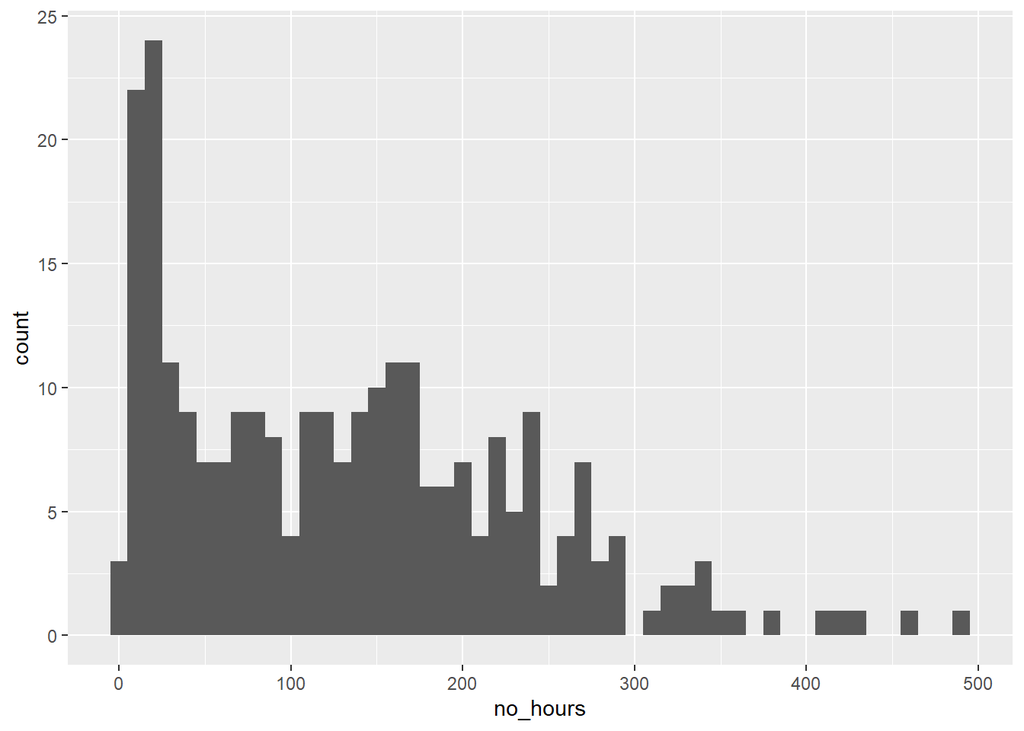

```r
#normality
# no_hours is non-normal requires transformation
histogram_hours_sqrt<-incu_new2 %>%ggplot(aes(x=no_hours))+
  geom_histogram (binwidth = 10)
histogram_hours_sqrt
```

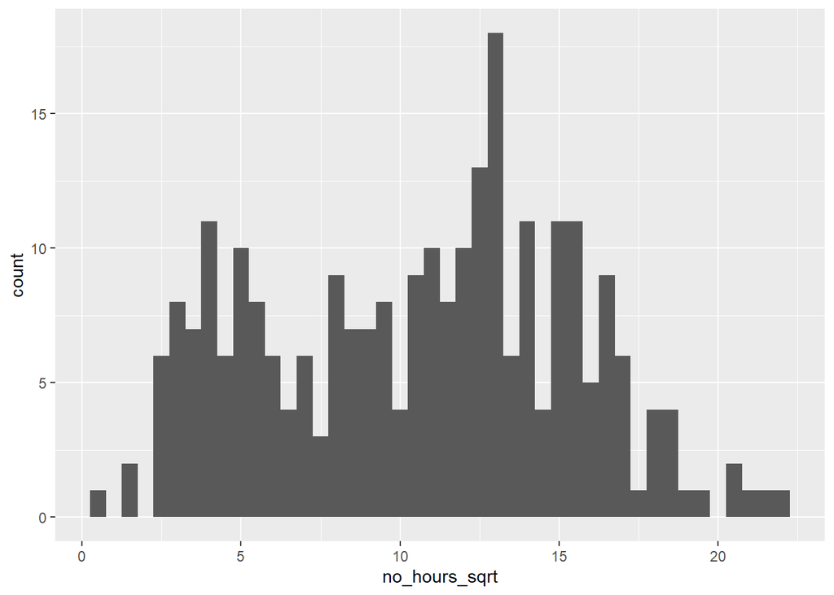

```r
# creating new sqrt response variable
incu_new2$no_hours_sqrt<-sqrt(incu_new2$no_hours)

#check success
histogram_hours_sqrt<-incu_new2 %>%ggplot(aes(x=no_hours_sqrt))+
 geom_histogram (binwidth = 0.5)
histogram_hours_sqrt
```

The variable `no_hours_sqrt` will be used as the response variable in the models.

Step 2: the following code is used to check each variable for homogeneity of variance.Output plots are omitted here for brevity.

```r
plot(lm(no_hours_sqrt~pers_sc,data=incu_new2))
```

```r
plot(lm(no_hours_sqrt~p_pers_sc,data=incu_new2))
```

```r
plot(lm(no_hours_sqrt~age_sc,data=incu_new2))
```

```r
plot(lm(no_hours_sqrt~age_sq_sc,data=incu_new2))
```

```r
plot(lm(no_hours_sqrt~p_age_sc,data=incu_new2))
```

```r
plot(lm(no_hours_sqrt~p_age_sq_sc,data=incu_new2))
```

```r
plot(lm(no_hours_sqrt~ppb_ave_diff_sc,data=incu_new2))
```

Step 3: this code searches for evidence of multicolinearity between potentially correlated continuous fixed variables. VIF scores > 3 are considered problematic.Code for the production of graphs has been provided by outputs are omitted for brevity.

```r
cor.test(incu_new2$age_sc,incu_new2$pers_sc) # view correlation
```

```
##
##  Pearson's product-moment correlation
##
## data:  incu_new2$age_sc and incu_new2$pers_sc
## t = 0.51054, df = 258, p-value = 0.6101
## alternative hypothesis: true correlation is not equal to 0
## 95 percent confidence interval:
##  -0.09023343  0.15283197
## sample estimates:
##        cor
## 0.03176897
```

```r
col_g<-incu_new2%>%ggplot(aes(x =age_sc , y =pers_sc))+
  geom_point(size=2)
col_g
```

```r
colin_model <- lm(no_hours_sqrt ~ age_sc +pers_sc, data = incu_new2)
summary(colin_model)
```

```
##
## Call:
## lm(formula = no_hours_sqrt ~ age_sc + pers_sc, data = incu_new2)
##
## Residuals:
##      Min       1Q   Median       3Q      Max
## -10.0912  -3.9329   0.5991   3.5304  11.0185
##
## Coefficients:
##             Estimate Std. Error t value Pr(>|t|)
## (Intercept)  10.5686     0.2950  35.830   <2e-16 ***
## age_sc       -0.4280     0.2957  -1.447    0.149
## pers_sc       0.3884     0.2957   1.314    0.190
## ---
## Signif. codes:  0 '***' 0.001 '**' 0.01 '*' 0.05 '.' 0.1 ' ' 1
##
## Residual standard error: 4.756 on 257 degrees of freedom
## Multiple R-squared:  0.01421,    Adjusted R-squared:  0.006535
## F-statistic: 1.852 on 2 and 257 DF,  p-value: 0.159
```

```r
vif(colin_model) #>3 = problematic
```

```
##  age_sc pers_sc
## 1.00101 1.00101
```

```r
#age and ppb
cor.test(incu_new2$age_sc,incu_new2$ppb_ave_diff_sc) #view correlation
```

```
##
##  Pearson's product-moment correlation
##
## data:  incu_new2$age_sc and incu_new2$ppb_ave_diff_sc
## t = 3.595e-16, df = 258, p-value = 1
## alternative hypothesis: true correlation is not equal to 0
## 95 percent confidence interval:
##  -0.1216537  0.1216537
## sample estimates:
##          cor
## 2.238166e-17
```

```r
col_g<-incu_new2%>%ggplot(aes(x =age_sc , y =ppb_ave_diff_sc))+
  geom_point(size=2)
col_g
```

```r
colin_model <- lm(no_hours_sqrt ~ age_sc +ppb_ave_diff_sc, data = incu_new2)
summary(colin_model)
```

```
##
## Call:
## lm(formula = no_hours_sqrt ~ age_sc + ppb_ave_diff_sc, data = incu_new2)
##
## Residuals:
##      Min       1Q   Median       3Q      Max
## -10.1331  -3.6887   0.4586   3.5538  10.1394
##
## Coefficients:
##                 Estimate Std. Error t value Pr(>|t|)
## (Intercept)      10.5686     0.2890  36.571  < 2e-16 ***
## age_sc           -0.4157     0.2895  -1.436 0.152350
## ppb_ave_diff_sc   1.0252     0.2895   3.541 0.000473 ***
## ---
## Signif. codes:  0 '***' 0.001 '**' 0.01 '*' 0.05 '.' 0.1 ' ' 1
##
## Residual standard error: 4.66 on 257 degrees of freedom
## Multiple R-squared:  0.05375,    Adjusted R-squared:  0.04639
## F-statistic: 7.299 on 2 and 257 DF,  p-value: 0.0008254
```

```r
vif(colin_model) #>3 = problematic
```

```
##          age_sc ppb_ave_diff_sc
##               1               1
```

```r
#age and p_age
cor.test(incu_new2$age_sc,incu_new2$p_age_sc) # view correlation
```

```
##
##  Pearson's product-moment correlation
##
## data:  incu_new2$age_sc and incu_new2$p_age_sc
## t = 14.636, df = 258, p-value < 2.2e-16
## alternative hypothesis: true correlation is not equal to 0
## 95 percent confidence interval:
##  0.6011335 0.7349642
## sample estimates:
##       cor
## 0.6735318
```

```r
col_g<-incu_new2%>%ggplot(aes(x =age_sc , y =p_age_sc))+
  geom_point(size=2)
col_g
```

```r
colin_model <- lm(no_hours_sqrt ~ age_sc +p_age_sc, data = incu_new2)
summary(colin_model)
```

```
##
## Call:
## lm(formula = no_hours_sqrt ~ age_sc + p_age_sc, data = incu_new2)
##
## Residuals:
##      Min       1Q   Median       3Q      Max
## -10.1740  -4.2080   0.6748   3.5055  10.9966
##
## Coefficients:
##             Estimate Std. Error t value Pr(>|t|)
## (Intercept)  10.5686     0.2957  35.736   <2e-16 ***
## age_sc       -0.5777     0.4009  -1.441    0.151
## p_age_sc      0.2406     0.4009   0.600    0.549
## ---
## Signif. codes:  0 '***' 0.001 '**' 0.01 '*' 0.05 '.' 0.1 ' ' 1
##
## Residual standard error: 4.769 on 257 degrees of freedom
## Multiple R-squared:  0.008977,   Adjusted R-squared:  0.001265
## F-statistic: 1.164 on 2 and 257 DF,  p-value: 0.3139
```

```r
vif(colin_model) #>3 = problematic
```

```
##   age_sc p_age_sc
## 1.830312 1.830312
```

```r
#pers and p_pers
cor.test(incu_new2$pers_sc,incu_new2$p_pers_sc) # view correlation
```

```
##
##  Pearson's product-moment correlation
##
## data:  incu_new2$pers_sc and incu_new2$p_pers_sc
## t = -9.6713, df = 258, p-value < 2.2e-16
## alternative hypothesis: true correlation is not equal to 0
## 95 percent confidence interval:
##  -0.5998380 -0.4205629
## sample estimates:
##        cor
## -0.5158254
```

```r
col_g<-incu_new2%>%ggplot(aes(x =age_sc , y =p_age_sc))+
  geom_point(size=2)
col_g
```

```r
colin_model <- lm(no_hours_sqrt ~ pers_sc +p_pers_sc, data = incu_new2)
summary(colin_model)
```

```
##
## Call:
## lm(formula = no_hours_sqrt ~ pers_sc + p_pers_sc, data = incu_new2)
##
## Residuals:
##      Min       1Q   Median       3Q      Max
## -10.0624  -3.8970   0.6179   3.5531  11.4408
##
## Coefficients:
##             Estimate Std. Error t value Pr(>|t|)
## (Intercept) 10.56858    0.29401  35.946   <2e-16 ***
## pers_sc      0.03046    0.34386   0.089   0.9295
## p_pers_sc   -0.66756    0.34386  -1.941   0.0533 .
## ---
## Signif. codes:  0 '***' 0.001 '**' 0.01 '*' 0.05 '.' 0.1 ' ' 1
##
## Residual standard error: 4.741 on 257 degrees of freedom
## Multiple R-squared:  0.02053,    Adjusted R-squared:  0.01291
## F-statistic: 2.694 on 2 and 257 DF,  p-value: 0.06953
```

```r
vif(colin_model) #>3 = problematic
```

```
##   pers_sc p_pers_sc
##  1.362539  1.362539
```

### Assumption Testing: Brooding

Once again, steps 1-3 above are repeated this time for the brooding subset.

Step 1: transformation of the response variable into `no_hour_sqrt`.

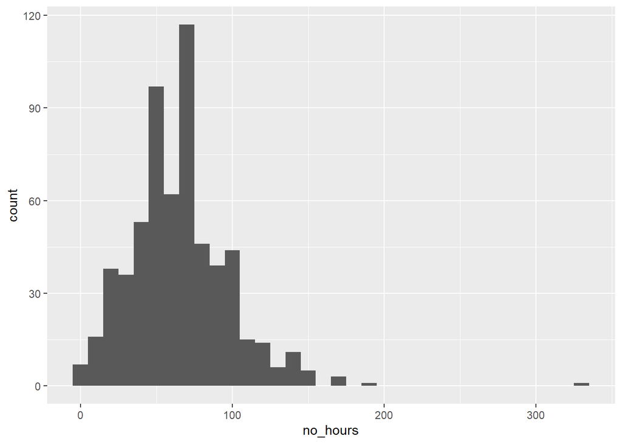

```r
#no_hour is non normal and requires transformation
histogram_hours_sqrt<-brood_new2 %>%ggplot(aes(x=no_hours))+
geom_histogram (binwidth = 10)
histogram_hours_sqrt
```

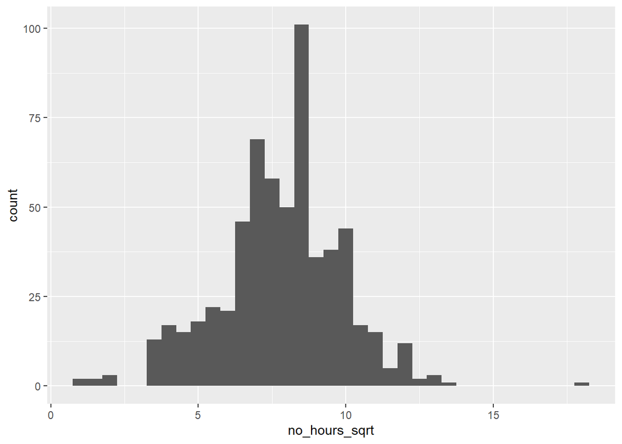

```r
# creating new sqrt response variable
brood_new2$no_hours_sqrt<-sqrt(brood_new2$no_hours)

# check success
histogram_hours_sqrt<-brood_new2 %>%ggplot(aes(x=no_hours_sqrt))+
geom_histogram (binwidth = 0.5)
histogram_hours_sqrt
```

The variable `no_hours_sqrt` will be used as the response variable in the models.

Step 2: check each variable for homogeneity of variance. Output plots are omitted here for brevity.

```r
plot(lm(no_hours_sqrt~pers_sc,data=brood_new2))
```

```r
plot(lm(no_hours_sqrt~age_sc,data=brood_new2))
```

```r
plot(lm(no_hours_sqrt~age_sq_sc,data=brood_new2))
```

```r
plot(lm(no_hours_sqrt~p_pers_sc,data=brood_new2))
```

```r
plot(lm(no_hours_sqrt~p_age_sc,data=brood_new2))
```

```r
plot(lm(no_hours_sqrt~p_age_sq_sc,data=brood_new2))
```

```r
plot(lm(no_hours_sqrt~ppb_ave_diff_sc,data=brood_new2))
```

Step 3: examine evidence of multicolinearity between potentially correlated continuous fixed variables. VIF scores > 3 are considered problematic. Code for the production of graphs has been provided by outputs are omitted for brevity.

```r
#pers and age
cor.test(brood_new2$age_sc,brood_new2$pers_sc)
```

```
##
##  Pearson's product-moment correlation
##
## data:  brood_new2$age_sc and brood_new2$pers_sc
## t = 3.7603, df = 609, p-value = 0.0001861
## alternative hypothesis: true correlation is not equal to 0
## 95 percent confidence interval:
##  0.07217681 0.22723939
## sample estimates:
##       cor
## 0.1506345
```

```r
col_g<-brood_new2%>%ggplot(aes(x =age_sc , y =pers_sc))+
  geom_point(size=2)
col_g
```

```r
colin_model <- lm(no_hours_sqrt ~ age_sc +pers_sc, data = brood_new2)
summary(colin_model)
```

```
##
## Call:
## lm(formula = no_hours_sqrt ~ age_sc + pers_sc, data = brood_new2)
##
## Residuals:
##     Min      1Q  Median      3Q     Max
## -6.6498 -1.0646  0.1118  1.2052 10.2963
##
## Coefficients:
##              Estimate Std. Error t value Pr(>|t|)
## (Intercept)  7.816415   0.082708  94.506  < 2e-16 ***
## age_sc       0.004899   0.083731   0.059  0.95336
## pers_sc     -0.241064   0.083731  -2.879  0.00413 **
## ---
## Signif. codes:  0 '***' 0.001 '**' 0.01 '*' 0.05 '.' 0.1 ' ' 1
##
## Residual standard error: 2.044 on 608 degrees of freedom
## Multiple R-squared:  0.01368,    Adjusted R-squared:  0.01044
## F-statistic: 4.216 on 2 and 608 DF,  p-value: 0.01519
```

```r
library(car)
vif(colin_model) #>3 = problematic
```

```
##   age_sc  pers_sc
## 1.023218 1.023218
```

```r
#age and ppb
cor.test(brood_new2$age_sc,brood_new2$ppb_ave_diff_sc)
```

```
##
##  Pearson's product-moment correlation
##
## data:  brood_new2$age_sc and brood_new2$ppb_ave_diff_sc
## t = -8.1004e-17, df = 609, p-value = 1
## alternative hypothesis: true correlation is not equal to 0
## 95 percent confidence interval:
##  -0.07932005  0.07932005
## sample estimates:
##           cor
## -3.282467e-18
```

```r
col_g<-brood_new2%>%ggplot(aes(x =age_sc , y =ppb_ave_diff_sc))+
  geom_point(size=2)
col_g
```

```r
colin_model <- lm(no_hours_sqrt ~ age_sc +ppb_ave_diff_sc, data = brood_new2)
summary(colin_model)
```

```
##
## Call:
## lm(formula = no_hours_sqrt ~ age_sc + ppb_ave_diff_sc, data = brood_new2)
##
## Residuals:
##     Min      1Q  Median      3Q     Max
## -6.9504 -1.1158  0.2231  1.1766 10.1607
##
## Coefficients:
##                 Estimate Std. Error t value Pr(>|t|)
## (Intercept)      7.81642    0.08297  94.208   <2e-16 ***
## age_sc          -0.03141    0.08304  -0.378   0.7053
## ppb_ave_diff_sc  0.17436    0.08304   2.100   0.0362 *
## ---
## Signif. codes:  0 '***' 0.001 '**' 0.01 '*' 0.05 '.' 0.1 ' ' 1
##
## Residual standard error: 2.051 on 608 degrees of freedom
## Multiple R-squared:  0.007431,   Adjusted R-squared:  0.004166
## F-statistic: 2.276 on 2 and 608 DF,  p-value: 0.1036
```

```r
library(car)
vif(colin_model) #>3 = problematic
```

```
##          age_sc ppb_ave_diff_sc
##               1               1
```

```r
#age and p_age
cor.test(brood_new2$age_sc,brood_new2$p_age_sc)
```

```
##
##  Pearson's product-moment correlation
##
## data:  brood_new2$age_sc and brood_new2$p_age_sc
## t = 18.09, df = 609, p-value < 2.2e-16
## alternative hypothesis: true correlation is not equal to 0
## 95 percent confidence interval:
##  0.5370693 0.6404886
## sample estimates:
##       cor
## 0.5912039
```

```r
col_g<-brood_new2%>%ggplot(aes(x =age_sc , y =p_age_sc))+
  geom_point(size=2)
col_g
```

```r
colin_model <- lm(no_hours_sqrt ~ age_sc +p_age_sc, data = brood_new2)
summary(colin_model)
```

```
##
## Call:
## lm(formula = no_hours_sqrt ~ age_sc + p_age_sc, data = brood_new2)
##
## Residuals:
##     Min      1Q  Median      3Q     Max
## -6.8015 -1.1213  0.2078  1.1079 10.0146
##
## Coefficients:
##             Estimate Std. Error t value Pr(>|t|)
## (Intercept)  7.81642    0.08315  94.005   <2e-16 ***
## age_sc      -0.11262    0.10318  -1.091    0.276
## p_age_sc     0.13735    0.10318   1.331    0.184
## ---
## Signif. codes:  0 '***' 0.001 '**' 0.01 '*' 0.05 '.' 0.1 ' ' 1
##
## Residual standard error: 2.055 on 608 degrees of freedom
## Multiple R-squared:  0.003139,   Adjusted R-squared:  -0.0001402
## F-statistic: 0.9572 on 2 and 608 DF,  p-value: 0.3845
```

```r
library(car)
vif(colin_model) #>3 = problematic
```

```
##   age_sc p_age_sc
## 1.537331 1.537331
```

```r
#pers and p_pers
cor.test(brood_new2$pers_sc,brood_new2$p_pers_sc)
```

```
##
##  Pearson's product-moment correlation
##
## data:  brood_new2$pers_sc and brood_new2$p_pers_sc
## t = -1.2389, df = 609, p-value = 0.2159
## alternative hypothesis: true correlation is not equal to 0
## 95 percent confidence interval:
##  -0.12894722  0.02929656
## sample estimates:
##         cor
## -0.05014001
```

```r
col_g<-brood_new2%>%ggplot(aes(x =age_sc , y =p_age_sc))+
  geom_point(size=2)
col_g
```

```r
colin_model <- lm(no_hours_sqrt ~ pers_sc +p_pers_sc, data = brood_new2)
summary(colin_model)
```

```
##
## Call:
## lm(formula = no_hours_sqrt ~ pers_sc + p_pers_sc, data = brood_new2)
##
## Residuals:
##     Min      1Q  Median      3Q     Max
## -6.8613 -1.1276  0.1368  1.2093 10.0270
##
## Coefficients:
##             Estimate Std. Error t value Pr(>|t|)
## (Intercept)  7.81642    0.08204  95.277  < 2e-16 ***
## pers_sc     -0.25334    0.08221  -3.082  0.00215 **
## p_pers_sc   -0.25958    0.08221  -3.158  0.00167 **
## ---
## Signif. codes:  0 '***' 0.001 '**' 0.01 '*' 0.05 '.' 0.1 ' ' 1
##
## Residual standard error: 2.028 on 608 degrees of freedom
## Multiple R-squared:  0.02959,    Adjusted R-squared:  0.0264
## F-statistic: 9.269 on 2 and 608 DF,  p-value: 0.0001083
```

```r
library(car)
vif(colin_model) #>3 = problematic
```

```
##   pers_sc p_pers_sc
##   1.00252   1.00252
```